# Introduction to Anomaly Detection

1. What is an anomaly?
2. Categories of different anomalies
3. What is anomaly detection?
4. Where is anomaly detection used?
5. The Basic Outlier Detection Models

## 1. What Is an Anomaly?

Generally, an **anomaly** is an outcome or value that deviates from what is expected, but the exact criteria for what determines an anomaly can vary from situation to situation

[figure not shown]

### 1.1. Anomalies as Data Points

[figure not shown]

### 1.2. Anomalies in a Time Series

[figure not shown]

## 2. Categories of Anomalies

- Data point-based anomalies
- Context-based anomalies
- Pattern-based anomalies

[figure not shown]

### 2.1. Data Point-Based Anomalies

Anomalies and outliers are not the same thing.

**Outliers** are data points that are expected to be present in the data set and can be caused by unavoidable random errors or from systematic errors relating to how the data was sampled.

**Anomalies** are outliers or other values that one doesn’t expect to exist. These types of anomalies can be found wherever a data set of values exists.

Difference between anomalies and outliers: you should expect there to be outliers in a set of data, but not anomalies.

### 2.2. Context-based anomalies

Context-based anomalies consist of data points that might seem normal at first, but are considered anomalies in their respective contexts.

For example, you might expect a sudden surge in purchases near certain holidays, but these purchases could seem out of place in the middle of August.

### 2.3. Pattern-based anomalies

Pattern-based anomalies are patterns and trends that deviate from their historical counterparts.

If an external hacker decided to DDOS the company’s website (DDOS, or a distributed denial-of-service attack, is an attempt to overwhelm the server that handles network flow to a certain website in an attempt to bring the entire website down or stop its functionality), every single attempt would register as an unusual spike in network traffic. All of these spikes are clearly deviants from normal traffic and would be considered anomalous.

## 3. What is anomaly detection?

**Anomaly detection** is the process in which an advanced algorithm identifies certain data or data patterns to be anomalous.

Heavily related to anomaly detection are the tasks of **outlier detection**, **noise removal**, and **novelty detection**.

### 3.1. Outlier Detection

**Outlier detection** is a technique that aims to detect anomalous outliers within a given data set.

Three methods:

1. to train only on normal data to identify anomalies by a high reconstruction error
2. to model a probability distribution in which anomalies are labeled based on their association with really low probabilities
3. to train a model to recognize anomalies by teaching it what an anomaly looks like and what a normal point looks like

### 3.2. Noise Removal

In **noise removal**, there is constant background noise in the data set that must be filtered out.

Imagine that you are at a party and you are talking to your friend. There is a lot of background noise, but your brain focuses on your friend’s voice and isolates it because that’s what you want to hear. Similarly, the model learns an efficient way to represent the original data so that it can reconstruct it without the anomalous interference noise.

### 3.3. Novelty Detection

**Novelty detection** is very similar to outlier detection.

The key difference between **novelty detection** and **outlier detection** is that in outlier detection, the job of the model is to determine what is an anomaly within the training data set. In novelty detection, the model learns what is a normal data point and what isn’t, and tries to classify anomalies in a new data set that it has never seen before.

A **novelty** is a data point outside of the training set.

### 3.4. The Three Styles of Anomaly Detection

- Supervised anomaly detection
  - Labels available for both normal data and anomalies
  - Similar to rare class mining
- Semi-supervised anomaly detection
  - Labels available only for normal data
- Unsupervised anomaly detection
  - No labels assumed
  - Based on the assumption that anomalies are very rare compared to normal data

#### 3.4.1. Supervised anomaly detection

**Supervised anomaly detection** is a technique in which the training data has labels for both anomalies and for normal data points.

Basically is **binary classification task**.

Unfortunately, this isn’t the most practical method of training, especially because the entire data set needs to be processed and each data point needs to be labeled.

Example - Temporal Convolutional Network.

#### 3.4.2. Semi-supervised anomaly detection

**Semi-supervised anomaly detection** involves partially labeling the training data set.

In the context of anomaly detection, this can be a case where only the normal data is labeled. Ideally, the model will learn what normal data points look like, so that the model can flag anomalous data points as anomalies since they differ from normal data points.

Example - Autoencoder.

#### 3.4.3. Unsupervised anomaly detection

**Unsupervised anomaly detection** involves training the model on unlabeled data. After the training process, the model is expected to know what data points are normal and what points are anomalous within the data set.

Example - Isolation Forest.

## 4. Where is anomaly detection used?

- **Cybersecurity**
  - Privacy
  - Malware Detection
  - Fraudulent Email
- **Finance**
  - Credit Card Fraud
  - Creditworthiness
  - Bankruptcy Prediction
  - Investing
- **Healthcare**
  - Diagnosis
  - Patient Monitoring
  - Radiology
  - Epidemiology
- **Defense and Internal Security**
  - Personnel Behaviors
  - Battlefield Behaviors
  - Unconventional Attacks
- **Consumer Home Safety**
  - Detecting Occurrence of Falls and Other Problems
  - Home Perimeter Safety
  - Indoor Pollution Monitoring
- **Manufacturing and Industry**
  - Quality Control
  - Retail Sales
  - Inventory Management
  - Customer Behavior
  - Employee Behavior
- **Science**

## 5. The Basic Outlier Detection Models

- Extreme-Value Analysis
- Probabilistic and Statistical Models
- Linear Models
- Proximity-Based Models
- Information-Theoretic Models

### 5.1. Extreme-Value Analysis

### 5.2. Probabilistic and Statistical Models

### 5.3. Linear Models

### 5.2. Proximity-Based Outlier Detection

**Proximity-based techniques** define a data point as an outlier when its locality (or proximity) is sparsely populated.

- Cluster-based
- Distance-based
- Density-based

#### 5.2.1. Cluster-based

The non-membership of a data point in any of the clusters, its distance from other clusters, the size of the closest cluster, or a combination of these factors are used to quantify the outlier score.

- Nearest Neighbor Clustering
- k-Means Clustering
- Fuzzy Clustering
- Agglomerative Clustering
- **DBSCAN: Density-Based Spatial Clustering of Applications with Noise**
- Divisive Clustering

#### 5.2.2. Distance-based

The distance of a data point to its k-nearest neighbor (or other variant) is used in order to define proximity. Data points with large k-nearest neighbor distances are defined as outliers.

- Similarity Measures
  - Direct measures: Euclidean, Minkowski, Mahalanobis distance; cosine similarity; Jaccard index
  - Indirect measures: Shared Nearest Neighbor (SNN)
- Distance to All Points
- Distance to Nearest Neighbor
- Average Distance to k Nearest Neighbors
- Median Distance to k Nearest Neighbors

#### 5.2.3. Density-based

The number of other points within a specified local region (grid region or distance-based region) of a data point, is used in order to define local density. These local density values may be converted into outlier scores.

- **LOF: Local Outlier Factor**
- LOCI: Local Correlation Integral
- Histogram-Based Techniques
- Kernel Density Estimation

# Outlier Detection

```python
import pandas as pd
import numpy as np
import scipy as sp
from scipy.stats import chi2
import matplotlib.pyplot as plt
import seaborn as sns
%matplotlib inline
from sklearn.datasets import make_blobs
from scipy import stats
import matplotlib.font_manager
from sklearn.metrics import accuracy_score, f1_score, precision_score, recall_score, roc_auc_score

# PyOD
from tensorflow.keras import backend as k
from pyod.utils.data import generate_data
from pyod.models.auto_encoder import AutoEncoder
#from keras.utils import plot_model
from tensorflow.keras.utils import plot_model

#Using TensorFlow backend.
from keras.utils.vis_utils import model_to_dot
from IPython.display import SVG

from sklearn.utils import shuffle
from sklearn.model_selection import train_test_split

#Import models
from pyod.models.abod import ABOD
from pyod.models.cblof import CBLOF
from pyod.models.feature_bagging import FeatureBagging
from pyod.models.hbos import HBOS
from pyod.models.iforest import IForest
from pyod.models.knn import KNN
from pyod.models.lof import LOF
from pyod.models.xgbod import XGBOD
from sklearn.svm import OneClassSVM

import pyod
from sklearn.ensemble import IsolationForest
from pyod.utils.example import visualize
from sklearn.model_selection import GridSearchCV
from sklearn.neighbors import LocalOutlierFactor
from sklearn.covariance import EllipticEnvelope
from sklearn.cluster import DBSCAN
from sklearn.preprocessing import StandardScaler
from sklearn.preprocessing import MinMaxScaler
from sklearn.preprocessing import RobustScaler

from sklearn import metrics
import matplotlib.ticker as ticker
from IPython.display import Image
import warnings
warnings.filterwarnings("ignore") # отключение варнингов
```

# Statistical Methods

## Generator 1

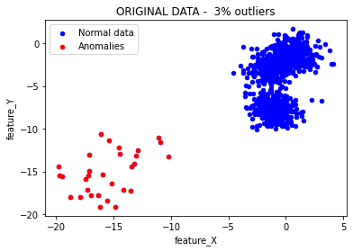

```python
contamination = 0.03
n = 1000 # длина выборки
n_out = 30 # число выбросов - 3%

#np.random.RandomState(1)
np.random.seed(3)
from sklearn.datasets import make_blobs
X = make_blobs(n_samples=n, n_features=2, centers=3, random_state=2, center_box=(-8.0, 8.0))[0]
X[:n_out,:] = 10*np.random.rand(n_out, 2) - 20
y = np.ones(n)
y[:n_out] = -1
plt.scatter(X[:,0], X[:,1], c='#0000FF', s=20, label='Normal data')
plt.scatter(X[:n_out,0], X[:n_out,1], c='#FF0000', s=20, label='Anomalies')
plt.xlabel('feature_X')
plt.ylabel('feature_Y')
plt.title('ORIGINAL DATA -  3% outliers')
plt.legend()
```

## Generator 2

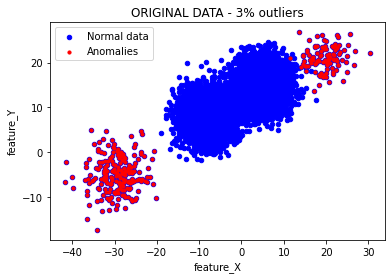

```python
contamination = 0.03 # % (percentage) of outliers
n_train = 10000  # number of training points
n_test_size = 0.3  # %  (percentage)  of testing points
n_features = 2 # Number of features


n_out = int(n_train*contamination) # число выбросов
n_out_1 = int(n_out/3)
n_out_2 = n_out - (n_out_1)

np.random.RandomState(42)
np.random.seed(40)
from sklearn.datasets import make_blobs
#centers = [[10, 1], [-1, -1], [5, 10]]
#centers = [[-10, -10], [10, 15],[30, 30]]
centers = [[-8, 8], [5, 15]] #anomal

X = make_blobs(n_samples=n_train, n_features=n_features, centers=centers, random_state=1,
               cluster_std=3)[0] # center_box=(-10.0, 10.0)
#X[:n_out,:] = 10*np.random.rand(n_out, 2)-10
#Первый центр выбросов
X[:n_out_1,:] = np.random.normal(20, 3, size=(n_out_1, 2))
X[:n_out_1,1]  = X[:n_out_1,1] + 1
#Второй центр выбросов
X[n_out_1:n_out,:] = np.random.normal(10, 4, size=(n_out_2, 2))
X[n_out_1:n_out,1] = X[n_out_1:n_out,1] -15
X[n_out_1:n_out,0] = X[n_out_1:n_out,0] -40

y = np.zeros(n_train)
y[:n_out] = 1
plt.scatter(X[:,0], X[:,1], c='#0000FF',s=20, label='Normal data')
plt.scatter(X[:n_out,0], X[:n_out,1], c='#FF0000', s=10, label='Anomalies')
plt.xlabel('feature_X')
plt.ylabel('feature_Y')
plt.title('ORIGINAL DATA - 3% outliers')
plt.legend()
```

# Generator 3

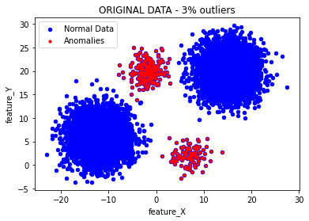

```python
contamination = 0.03  # % (percentage) of outliers
n_train = 10000  # number of training points
n_test_size = 0.3  # %  (percentage)  of testing points
n_features = 2 # Number of features


n_out = int(n_train*contamination) # число выбросов
n_out_1 = int(n_out/3)
n_out_2 = n_out - (n_out_1)

np.random.RandomState(42)
np.random.seed(40)
from sklearn.datasets import make_blobs

centers = [[-12, 6], [15, 20]] #anomal

X = make_blobs(n_samples=n_train, n_features=n_features, centers=centers, random_state=1,
               cluster_std=3)[0] # center_box=(-10.0, 10.0)
#X[:n_out,:] = 10*np.random.rand(n_out, 2)-10
#First  outliers center
X[:n_out_1,:] = np.random.normal(7, 2, size=(n_out_1, 2))
X[:n_out_1,1]  = X[:n_out_1,1] - 5
#Second  outliers center
X[n_out_1:n_out,:] = np.random.normal(10, 2, size=(n_out_2, 2))
X[n_out_1:n_out,1] = X[n_out_1:n_out,1] +10
X[n_out_1:n_out,0] = X[n_out_1:n_out,0] -12

y = np.zeros(n_train)
y[:n_out] = 1
plt.scatter(X[:,0], X[:,1], c='#0000FF',s=20, label='Normal Data')
plt.scatter(X[:n_out,0], X[:n_out,1], c='#FF0000', s=10, label='Anomalies')
plt.xlabel('feature_X')
plt.ylabel('feature_Y')
plt.title('ORIGINAL DATA - 3% outliers')
plt.legend()
```

```python
orig_data = Image("img/orig_data.png")
```

#### Visualization of feature distributions

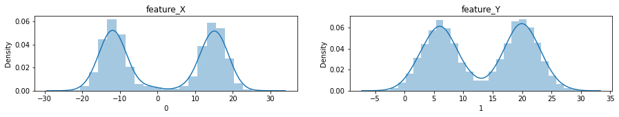

```python
data = pd.DataFrame(X)
data.columns =['0', '1']
fig, ax = plt.subplots(figsize=(15,2), ncols=2, nrows=1)
sns.distplot(data['0'], ax=ax[0])
sns.distplot(data['1'], ax=ax[1])
ax[0].set_title("feature_X")
ax[1].set_title("feature_Y")
```

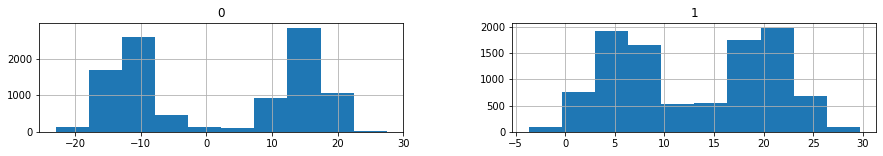

```python
data.hist(figsize=(15, 2));
```

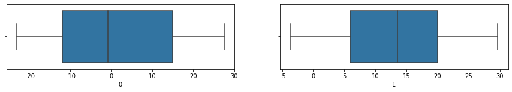

```python
_, axes = plt.subplots(1, 2, sharey=True, figsize=(15, 2))
sns.boxplot(x=data['0'],ax=axes[0])
sns.boxplot(x=data['1'],ax=axes[1])
```

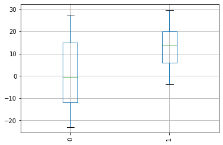

```python
data.boxplot()
plt.xticks(rotation='vertical')
#plt.yscale('log')
plt.show()
```

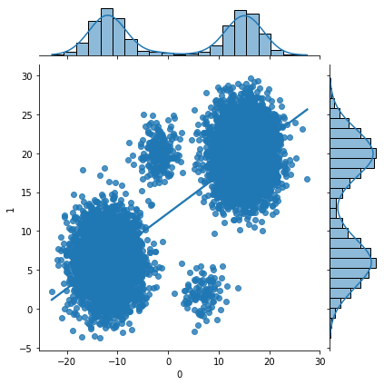

```python
sns.jointplot(x='0', y='1', data=data, kind='reg');
```

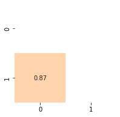

```python
plt.figure(figsize=(3,3))
corr_matrix = data.corr()
lower = corr_matrix.where(np.tril(np.ones(corr_matrix.shape), k=-1).astype(np.bool))
sns.heatmap(lower, annot=True, fmt='.2f', cbar=False, center=0);
```

```python
high_corr = [
    column for column in lower.columns if any((lower[column] > 0.3)|(lower[column] < -0.6))
]
high_corr
```

```
['0']
```

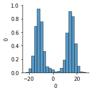

```python
other_features = [col for col in data.columns if col not in high_corr and col!='quality']
sns.pairplot(data[high_corr]);
```

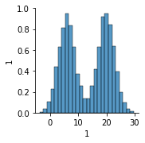

```python
sns.pairplot(data[other_features]);
```

# Statistical Methods

#### 3 sigma anomaly detection

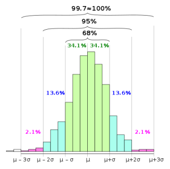

```python
Image("img/3_sigma_rule.png")
```

```python
def outlier_std(data, col, threshold=3):
    mean = data[col].mean()
    std = data[col].std()
    up_bound = mean + threshold * std
    low_bound = mean - threshold * std
    anomalies = pd.concat([data[col]>up_bound, data[col]<low_bound], axis=1).any(1)

    return anomalies, up_bound, low_bound

def get_column_outliers(data, columns=None, function=outlier_std, threshold=3):
    if columns:
        columns_to_check = columns
    else:
        columns_to_check = data.columns

    outliers = pd.Series(data=[False]*len(data), index=data_features.index, name='is_outlier')
    comparison_table = {}
    for column in columns_to_check:
        anomalies, upper_bound, lower_bound = function(data, column, threshold=threshold)
        comparison_table[column] = [upper_bound, lower_bound, sum(anomalies), 100*sum(anomalies)/len(anomalies)]
        outliers[anomalies[anomalies].index] = True

    comparison_table = pd.DataFrame(comparison_table).T
    comparison_table.columns=['upper_bound', 'lower_bound', 'anomalies_count', 'anomalies_percentage']

    return comparison_table, outliers

def anomalies_report(outliers):
    print("Total number of outliers: {}\nPercentage of outliers:           {:.2f}%".format(
            sum(outliers), 100*sum(outliers)/len(outliers)))
```

```python
data_features = data.iloc[:, :]
comparison_table, std_outliers = get_column_outliers(data_features)
anomalies_report(std_outliers)
```

```
Total number of outliers: 0
Percentage of outliers:           0.00%
```

```python
comparison_table
```

|  | upper_bound | lower_bound | anomalies_count | anomalies_percentage |
| --- | --- | --- | --- | --- |
| 0 | 42.483829 | -39.431334 | 0.0 | 0.0 |
| 1 | 35.943485 | -9.871658 | 0.0 | 0.0 |

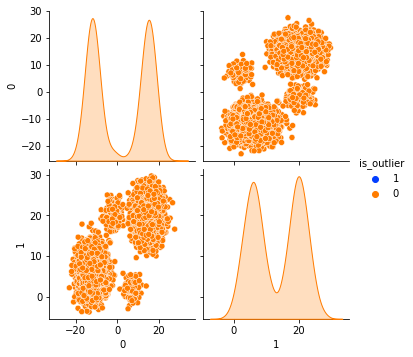

```python
other_features = [col for col in data.columns]
labeled_data = data_features.copy()
labeled_data['is_outlier'] = std_outliers

sns.pairplot(data=labeled_data, vars = other_features,
             hue='is_outlier', hue_order=[1, 0],
               palette='bright');
```

```python
data_features = data.iloc[:, :].copy()
scaler = RobustScaler()
scaled_data = pd.DataFrame(
    data=scaler.fit_transform(data_features),
    columns=data_features.columns
)
```

#### Visualization of original data and data after applying 3_Sigma

```python
def vizualisation_methods(labeled_data, name_method):
# anomalous data - RED
    fig, ax = plt.subplots(figsize=(12,3), nrows=1, ncols=2)

#Original
    plt.subplot(121)
    ax = fig.add_subplot(121)
    plt.scatter(X[:,0], X[:,1], c='#0000FF',s=20, label='Normal Data')
    plt.scatter(X[:n_out,0], X[:n_out,1], c='#FF0000', s=10, label='Anomalies')
    plt.xlabel('feature_X')
    plt.ylabel('feature_Y')
    plt.title('ORIGINAL DATA')
    plt.legend()

    plt.subplot(122)
    ax = fig.add_subplot(122)
    plt.scatter(labeled_data.iloc[:,0][labeled_data['is_outlier'] == False],
            labeled_data.iloc[:,1][labeled_data['is_outlier'] == False], c='#0000FF',s=20, label='Normal Data')

    plt.scatter(labeled_data.iloc[:,0][labeled_data['is_outlier'] == True],
            labeled_data.iloc[:,1][labeled_data['is_outlier'] == True], c='#FF0000', s=10, label='Anomalies')
    plt.xlabel('feature_X')
    plt.ylabel('feature_Y')
    plt.title(name_method)
    plt.legend()
    print(f"Percentage of Аnomalies: Original - {contamination*100} %;                           {name_method} - {100 - 100*len(labeled_data.iloc[:,0][labeled_data['is_outlier'] == False])/len(data):4.2f} %")
```

```
Percentage of Аnomalies: Original - 3.0 %;                           DATA after 3_Sigma - 0.00 %
```

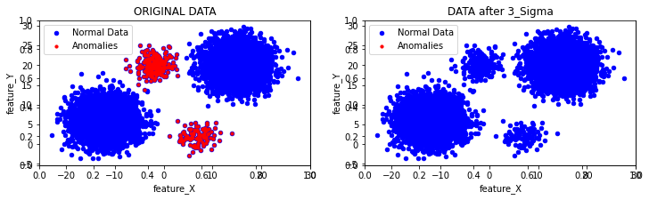

```python
vizualisation_methods(labeled_data, name_method ='DATA after 3_Sigma')
```

#### Defining Anomalies Using Quantile

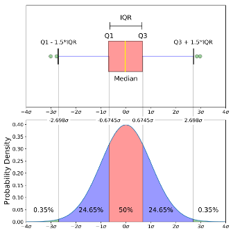

```python
Image("img/quantil_rule+.png")
```

```python
def outlier_iqr(data, col, threshold=3):
    IQR = data[col].quantile(0.75) - data[col].quantile(0.25)
    up_bound = data[col].quantile(0.75) + (IQR * threshold)
    low_bound = data[col].quantile(0.25) - (IQR * threshold)
    anomalies = pd.concat([data[col]>up_bound, data[col]<low_bound], axis=1).any(1)
    return anomalies, up_bound, low_bound
```

```python
comparison_table, iqr_outliers = get_column_outliers(data_features, function=outlier_iqr)
anomalies_report(iqr_outliers)
```

```
Total number of outliers: 0
Percentage of outliers:           0.00%
```

```python
comparison_table
```

[output not shown]

[figure not shown]

```python
labeled_data = data_features.copy()
labeled_data['is_outlier'] = iqr_outliers

sns.pairplot(data=labeled_data, vars = other_features,
             hue='is_outlier', hue_order=[1, 0],
             markers=['x', 'o'],  palette='bright');
```

#### Visualization of original data and data after applying Quantile

[output not shown]

[figure not shown]

```python
vizualisation_methods(labeled_data, name_method ='DATA after Quantile (0,25 - 0,75)')
```

### Z-score Method

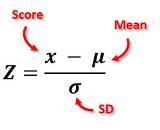

```python
Image("img/z_formula.jpg")
```

z-score (also called a standard score) gives you an idea of how far from the mean a data point is

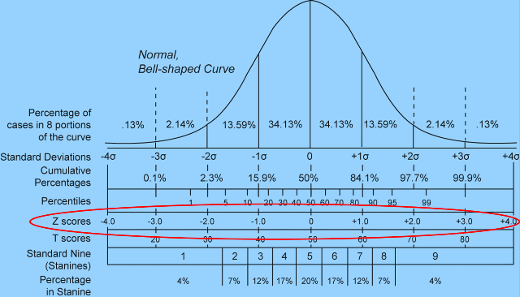

```python
Image("img/z_fig.png")
```

```python
#Filtering function by a given level Z-level
level = 3

def outliers(df, level):
    # Select a level for a Z-score to identify and remove outliers
    df_Z = df[(np.abs(stats.zscore(df)) < level).all(axis=1)]
    ix_keep = df_Z.index
    # Subset the raw dataframe with the indexes you'd like to keep
    df_keep_1 = df.loc[ix_keep]
    return(df_keep_1)

def no_outliers(df, level):
    # Select a level for a Z-score to identify and remove outliers
    df_Z = df[(np.abs(stats.zscore(df)) > level).all(axis=1)]
    ix_keep = df_Z.index
    # Subset the raw dataframe with the indexes you'd like to keep
    df_keep_2 = df.loc[ix_keep]
    return(df_keep_2)

# remove outliers
df_clean_z = outliers(df = data, level = level) # Отфильрованный датасет
df_no_out_z = no_outliers(df = data, level = level)# Выбросы
```

```python
#Getting Unfiltered OUTPUTS
temp1 = df_no_out_z
temp2 = data[:n_out]
not_filtered_z = temp2[~temp2.apply(tuple,1).isin(temp1.apply(tuple,1))]
print("Number of filtered points:", len(data)-len(df_clean_z))
print("NOT filtered Outliers")
not_filtered_z.head(2)
```

```
Number of filtered points: 0
NOT filtered Outliers
```

|  | 0 | 1 |
| --- | --- | --- |
| 0 | 5.784905 | 1.747727 |
| 1 | 5.630787 | 3.857429 |

```python
# Filtered Outliers
df_no_out_z.head(2)
```

[output not shown]

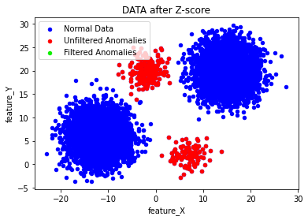

```python
# Z filtration
plt.scatter(df_clean_z['0'], df_clean_z['1'], c='#0000FF', s=20, label='Normal Data')
plt.scatter(not_filtered_z['0'], not_filtered_z['1'], c='#FF0000',s=20, label='Unfiltered Anomalies')
plt.scatter(df_no_out_z['0'], df_no_out_z['1'], c='#0FF000', s=20, label='Filtered Anomalies')
plt.xlabel('feature_X')
plt.ylabel('feature_Y')
plt.title('DATA after Z-score')
#ax.set_xlim([-20, 5])
#ax.set_ylim([-20, 2])
plt.legend()
```

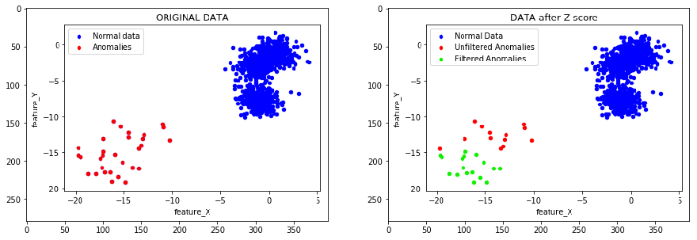

```python
image1 = plt.imread('img/orig_data_1.png')
image2 = plt.imread('img/z_score_1.png')
fig, ax = plt.subplots(1, 2)

ax[0].imshow(image1)
ax[1].imshow(image2)
#ax.set_title(type(image))

fig.set_figwidth(15)
fig.set_figheight(15)
plt.show()
```